# Functional Programming - Exercises 1

Aksel Thomsen

Statistical Programming with R

None of the problems depend on each other, so if you are stuck just continue to the next.

If in need of a hint just ask or consult one of the many cheat sheets ;)

Each problem can be solved in different ways.

## Problem 1

Create your own function to calculate the cummulative sum of a vector. For inspiration the base R function `cumsum` works like this:

```r
x <- 1:10
x
```

```
##  [1]  1  2  3  4  5  6  7  8  9 10
```

```r
cumsum(x)
```

```
##  [1]  1  3  6 10 15 21 28 36 45 55
```

The function should return the same.

**Solution 1**

```r
x <- 1:10
y <- x
for (i in 2:10) {
  y[[i]] <- x[[i]] + y[[i-1]]
}
x
```

```
##  [1]  1  2  3  4  5  6  7  8  9 10
```

```r
y
```

```
##  [1]  1  3  6 10 15 21 28 36 45 55
```

```r
cumsum(x)
```

```
##  [1]  1  3  6 10 15 21 28 36 45 55
```

```r
cumulative_sum <- function(x){
  y <- x
  for (i in 2:length(x)) {
    y[[i]] <- x[[i]] + y[[i-1]]
  }
  return(y)
}

cumulative_sum(1:7)
```

```
## [1]  1  3  6 10 15 21 28
```

**Solution 2**

```r
library(purrr)
accumulate(.x = 1:7, .f = sum)
```

```
## [1]  1  3  6 10 15 21 28
```

```r
cumulative_sum <- function(x){
  y <- accumulate(.x = x, .f = sum)
  return(y)
}

cumulative_sum(1:9)
```

```
## [1]  1  3  6 10 15 21 28 36 45
```

## Problem 2

Make a function that given two inputs of numeric vectors returns the pairwise mean. E.g. the following input:

```r
(x <- c(1,5,9))
```

```
## [1] 1 5 9
```

```r
(y <- c(2,4,0))
```

```
## [1] 2 4 0
```

Should return:

```r
c(1.5,4.5,4.5)
```

```
## [1] 1.5 4.5 4.5
```

**Solution 1**

```r
pmean <- function(x,y){
 stopifnot(length(x) == length(y))
  stopifnot(is.numeric(x) & is.numeric(y))
  out <- numeric(length = length(x))
  for (i in seq_len(length(x))) {
    out[[i]] <- mean(x[[i]],y[[i]])
  }

return(out)
}

pmean(x,y)
```

```
## [1] 1 5 9
```

```r
pmean(x,"a")
```

```
## Error in pmean(x, "a"): length(x) == length(y) is not TRUE
```

```r
pmean("A",1)
```

```
## Error in pmean("A", 1): is.numeric(x) & is.numeric(y) is not TRUE
```

**Solution 2**

```r
x
```

```
## [1] 1 5 9
```

```r
y
```

```
## [1] 2 4 0
```

```r
map2(.x = x, .y = y, .f = c) %>%
  map_dbl(.f = mean)
```

```
## [1] 1.5 4.5 4.5
```

## Problem 3

I have uploaded 5 different csv files with data on cars to the webpage (cars_1.csv - cars_5.csv). Download and read them all into R using functional programming, and combine them into one common `data.frame`.

**Solution 1**

```r
cars_1 <- readr::read_csv("cars_1.csv")
cars_2 <- readr::read_csv("cars_2.csv")
```

```r
library(tidyverse)

c("cars_1.csv","cars_2.csv","cars_3.csv","cars_4.csv","cars_5.csv") %>%
  map(.f = readr::read_csv) %>%
  bind_rows() %>%
  select(-X1)
```

```
## # A tibble: 32 x 12
##    car           mpg   cyl  disp    hp  drat    wt  qsec    vs    am  gear  carb
##    <chr>       <dbl> <dbl> <dbl> <dbl> <dbl> <dbl> <dbl> <dbl> <dbl> <dbl> <dbl>
##  1 Mazda RX4    21       6  160    110  3.9   2.62  16.5     0     1     4     4
##  2 Datsun 710   22.8     4  108     93  3.85  2.32  18.6     1     1     4     1
##  3 Chrysler I~  14.7     8  440    230  3.23  5.34  17.4     0     0     3     4
##  4 Toyota Cor~  21.5     4  120.    97  3.7   2.46  20.0     1     0     3     1
##  5 Dodge Chal~  15.5     8  318    150  2.76  3.52  16.9     0     0     3     2
##  6 Camaro Z28   13.3     8  350    245  3.73  3.84  15.4     0     0     3     4
##  7 Merc 230     22.8     4  141.    95  3.92  3.15  22.9     1     0     4     2
##  8 Maserati B~  15       8  301    335  3.54  3.57  14.6     0     1     5     8
##  9 Volvo 142E   21.4     4  121    109  4.11  2.78  18.6     1     1     4     2
## 10 Merc 450SL   17.3     8  276.   180  3.07  3.73  17.6     0     0     3     3
## # ... with 22 more rows
```

**Solution 2**

```r
list.files() %>%
  str_subset(".csv") %>%
  map_dfr(.f = readr::read_csv)
```

```
## # A tibble: 32 x 13
##       X1 car     mpg   cyl  disp    hp  drat    wt  qsec    vs    am  gear  carb
##    <dbl> <chr> <dbl> <dbl> <dbl> <dbl> <dbl> <dbl> <dbl> <dbl> <dbl> <dbl> <dbl>
##  1     1 Mazd~  21       6  160    110  3.9   2.62  16.5     0     1     4     4
##  2     2 Dats~  22.8     4  108     93  3.85  2.32  18.6     1     1     4     1
##  3     3 Chry~  14.7     8  440    230  3.23  5.34  17.4     0     0     3     4
##  4     4 Toyo~  21.5     4  120.    97  3.7   2.46  20.0     1     0     3     1
##  5     5 Dodg~  15.5     8  318    150  2.76  3.52  16.9     0     0     3     2
##  6     6 Cama~  13.3     8  350    245  3.73  3.84  15.4     0     0     3     4
##  7     1 Merc~  22.8     4  141.    95  3.92  3.15  22.9     1     0     4     2
##  8     2 Mase~  15       8  301    335  3.54  3.57  14.6     0     1     5     8
##  9     3 Volv~  21.4     4  121    109  4.11  2.78  18.6     1     1     4     2
## 10     1 Merc~  17.3     8  276.   180  3.07  3.73  17.6     0     0     3     3
## # ... with 22 more rows
```

## Problem 4

Create a histogram of each numeric variable in the cars data. It does not mather if you use `mtcars` or the data from Problem 3, nor wether the histogram is produced with base `hist` or produced with `ggplot`.

**Solution 1**

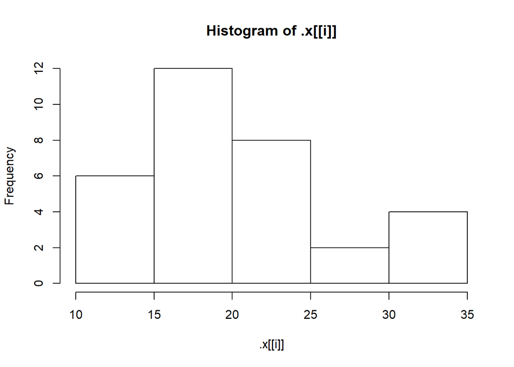

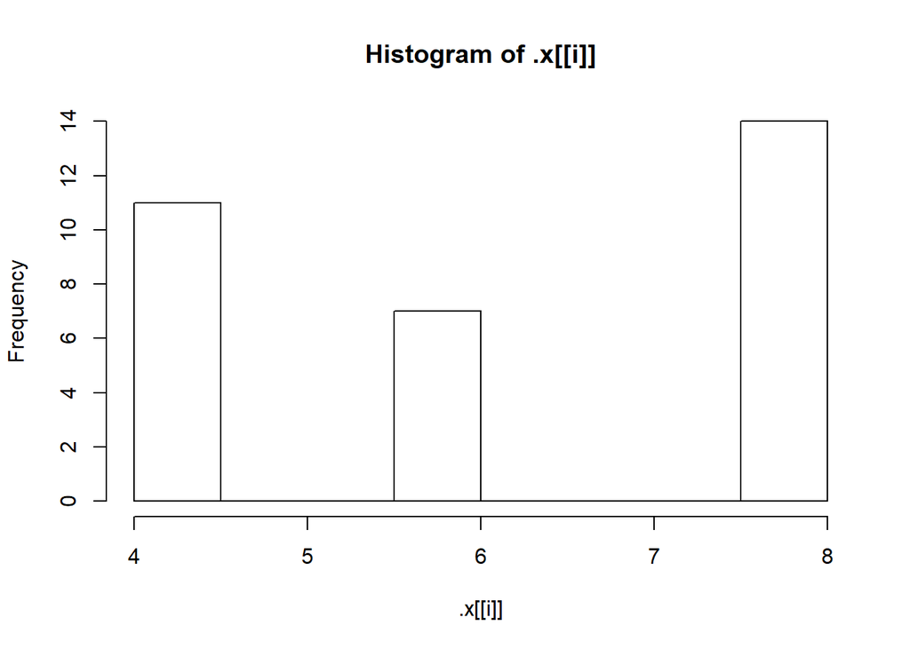

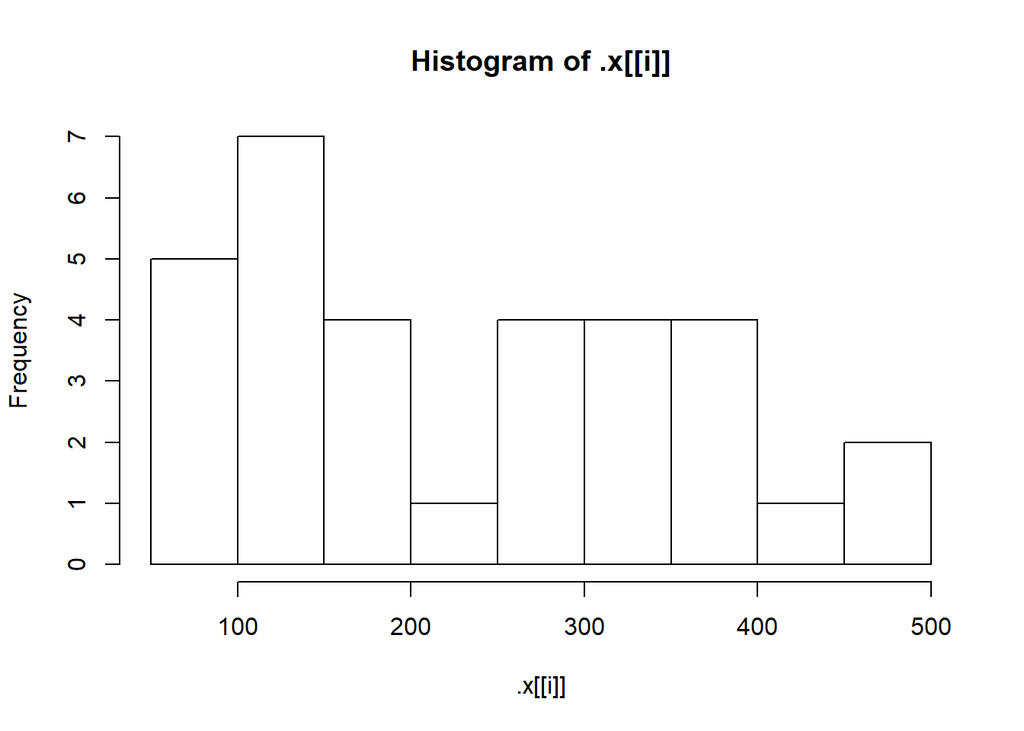

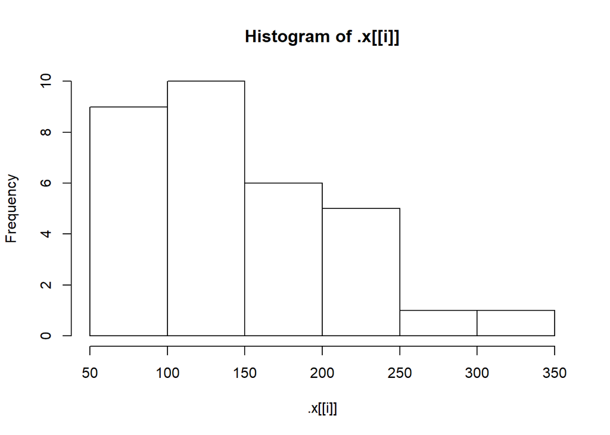

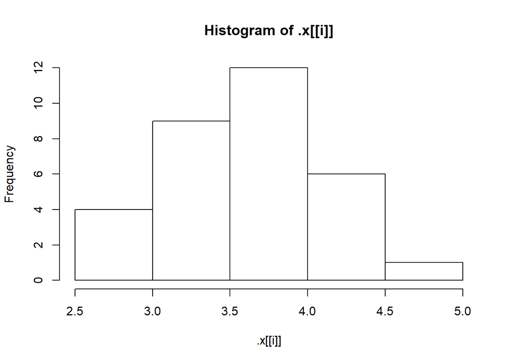

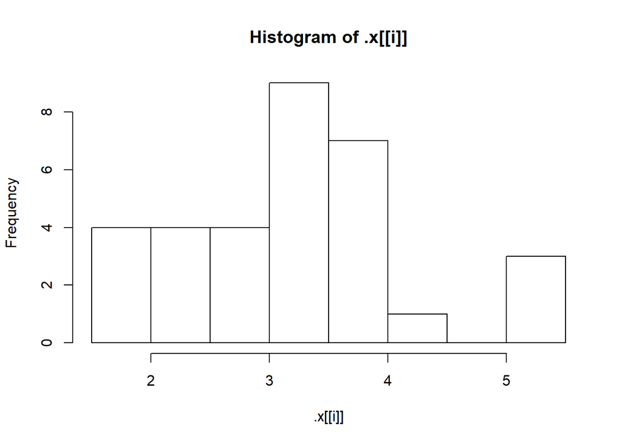

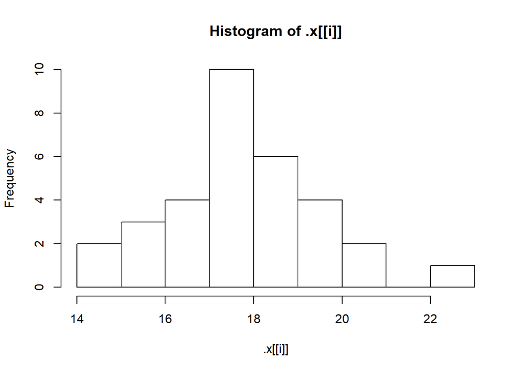

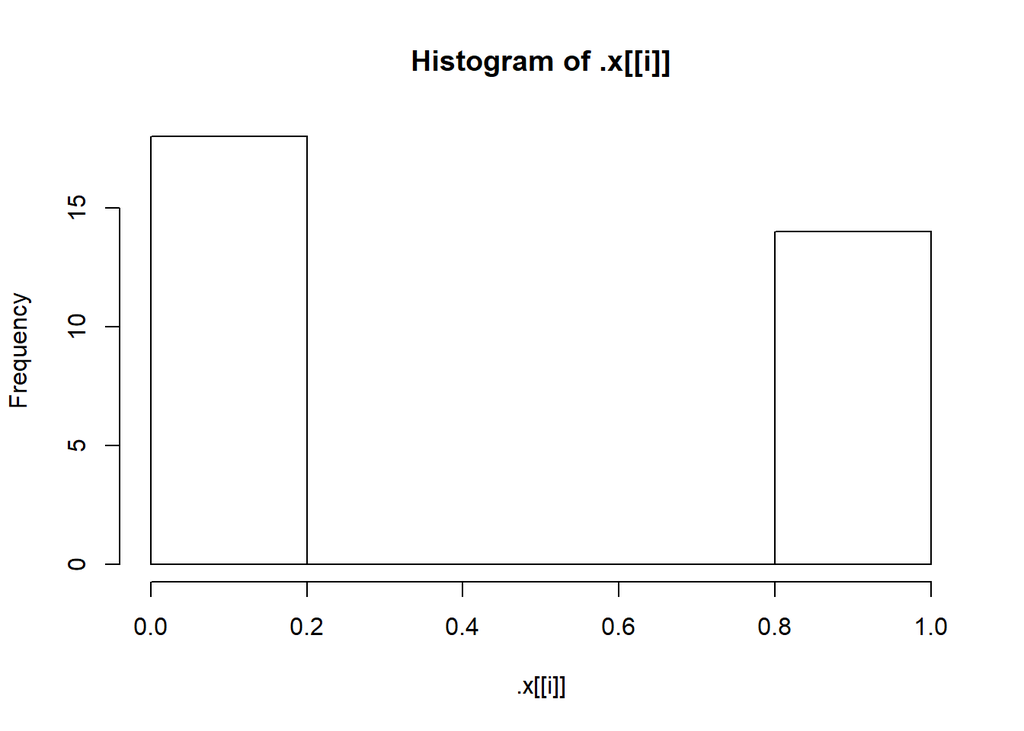

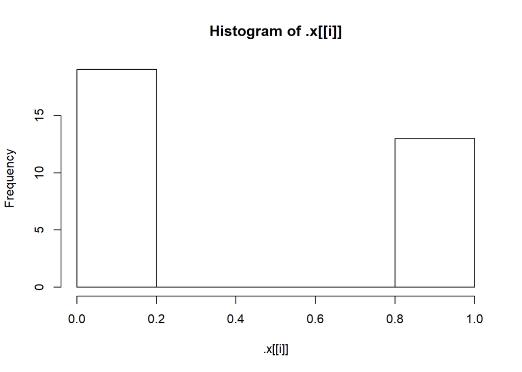

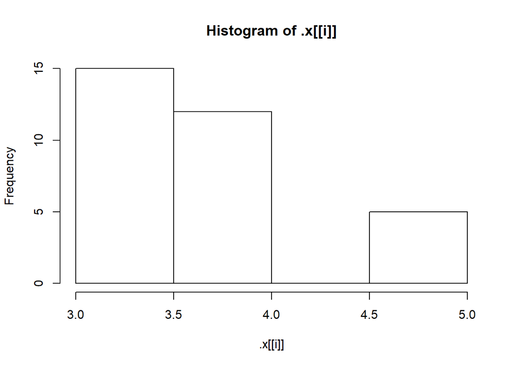

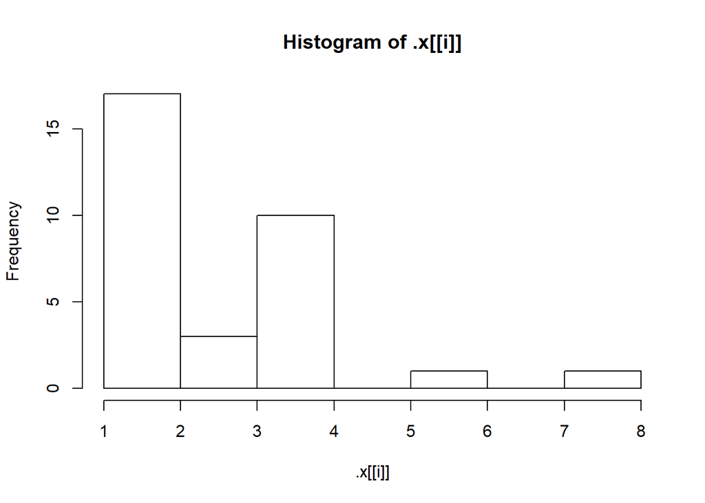

```r
as_tibble(mtcars) %>%
  walk(hist)
```

**Solution 2**

```r
x <- mtcars[3]
x
```

```
##                      disp
## Mazda RX4           160.0
## Mazda RX4 Wag       160.0
## Datsun 710          108.0
## Hornet 4 Drive      258.0
## Hornet Sportabout   360.0
## Valiant             225.0
## Duster 360          360.0
## Merc 240D           146.7
## Merc 230            140.8
## Merc 280            167.6
## Merc 280C           167.6
## Merc 450SE          275.8
## Merc 450SL          275.8
## Merc 450SLC         275.8
## Cadillac Fleetwood  472.0
## Lincoln Continental 460.0
## Chrysler Imperial   440.0
## Fiat 128             78.7
## Honda Civic          75.7
## Toyota Corolla       71.1
## Toyota Corona       120.1
## Dodge Challenger    318.0
## AMC Javelin         304.0
## Camaro Z28          350.0
## Pontiac Firebird    400.0
## Fiat X1-9            79.0
## Porsche 914-2       120.3
## Lotus Europa         95.1
## Ford Pantera L      351.0
## Ferrari Dino        145.0
## Maserati Bora       301.0
## Volvo 142E          121.0
```

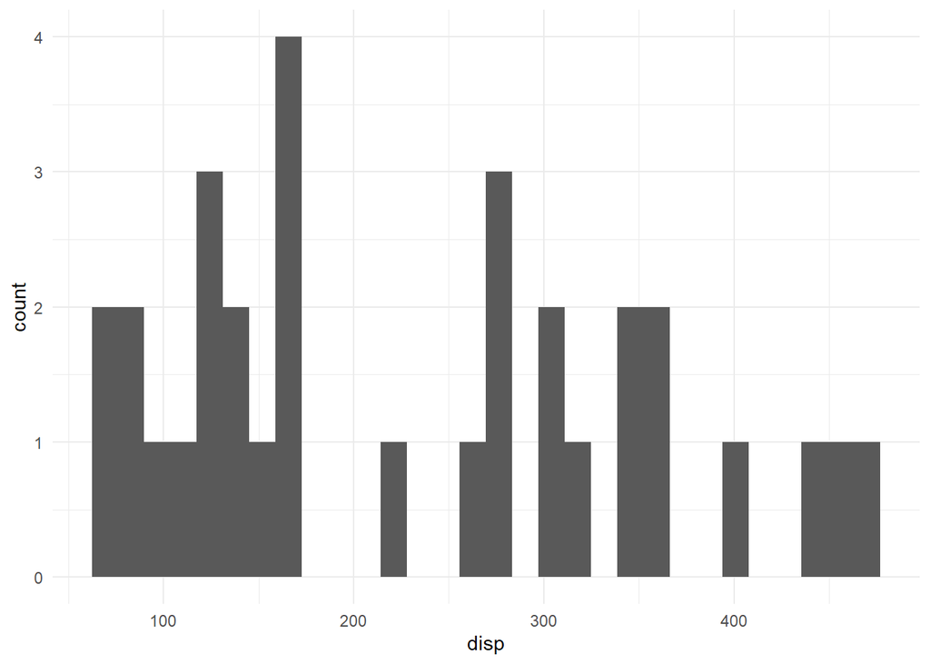

```r
ggplot(mapping = aes(x = x[[1]])) +
  geom_histogram() +
  labs(x = names(x[1])) +
  theme_minimal()
```

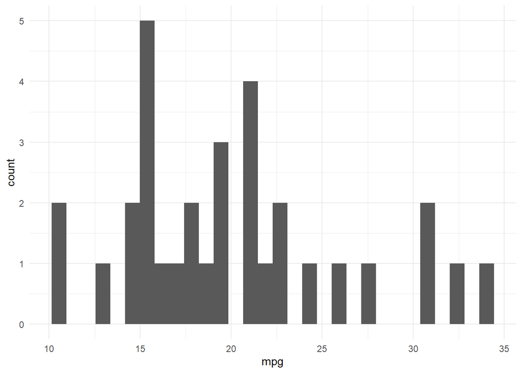

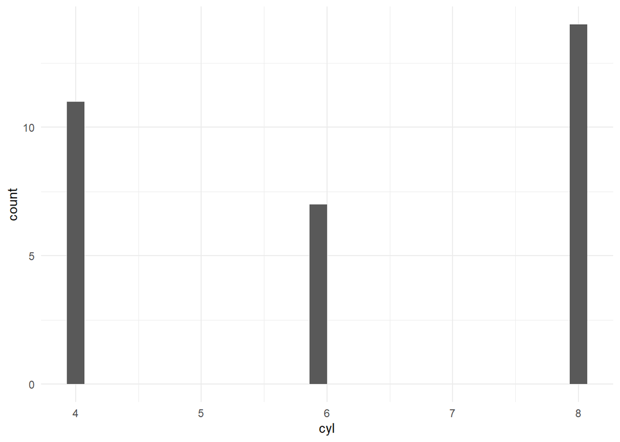

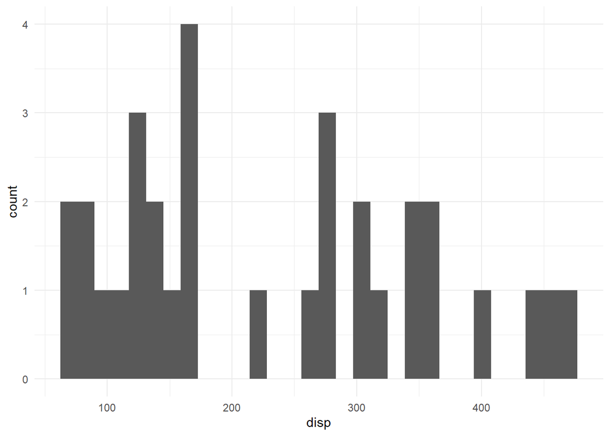

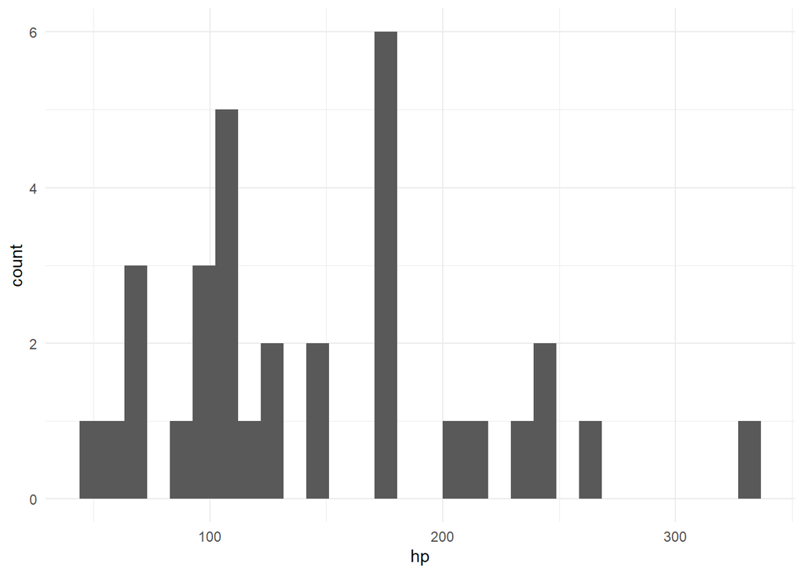

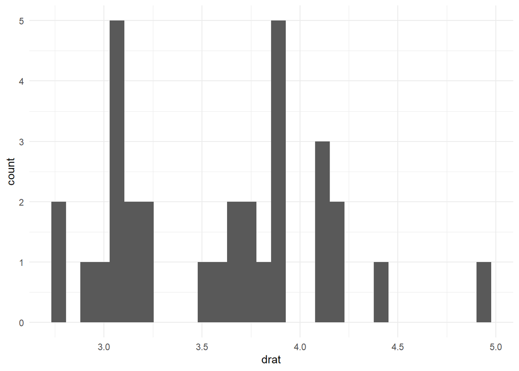

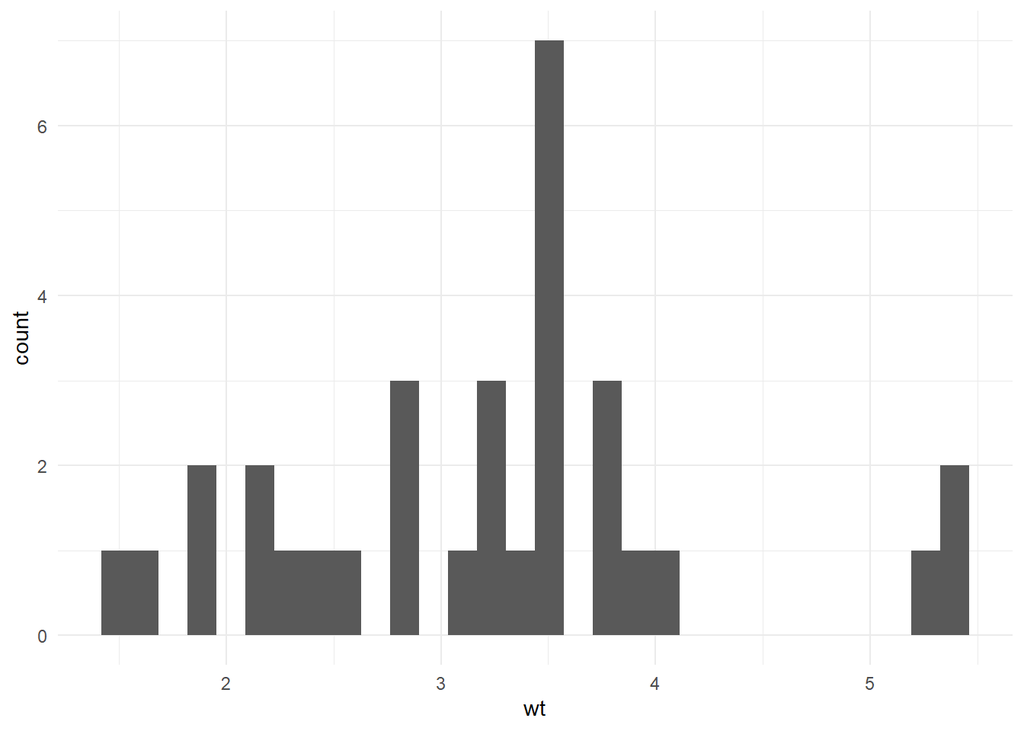

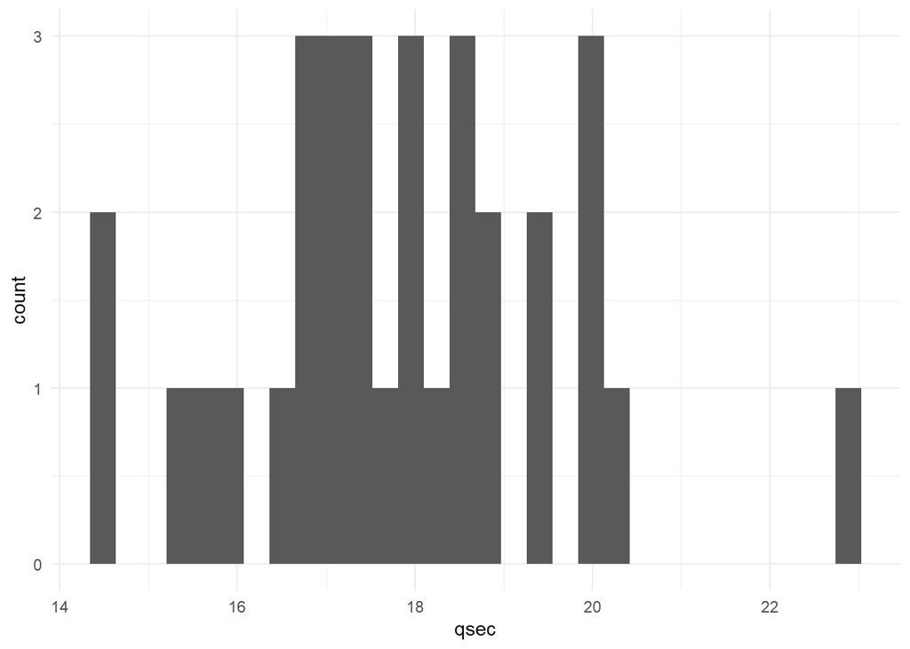

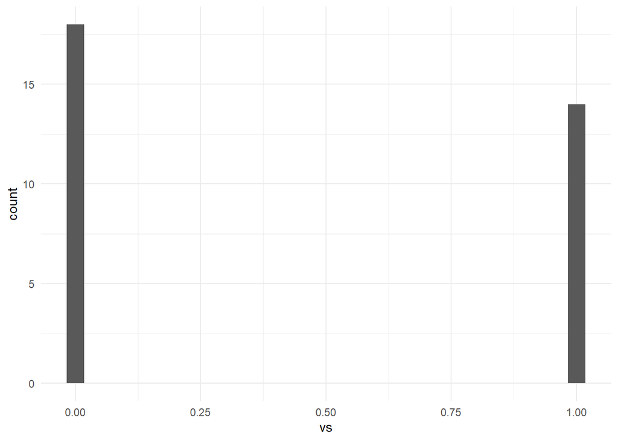

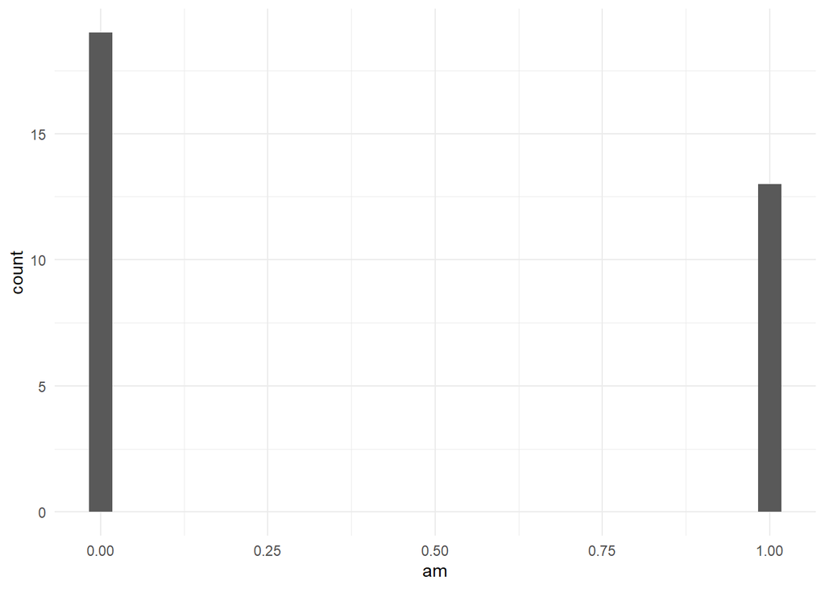

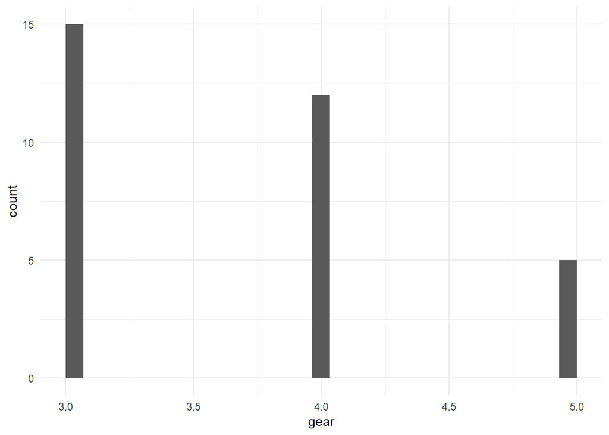

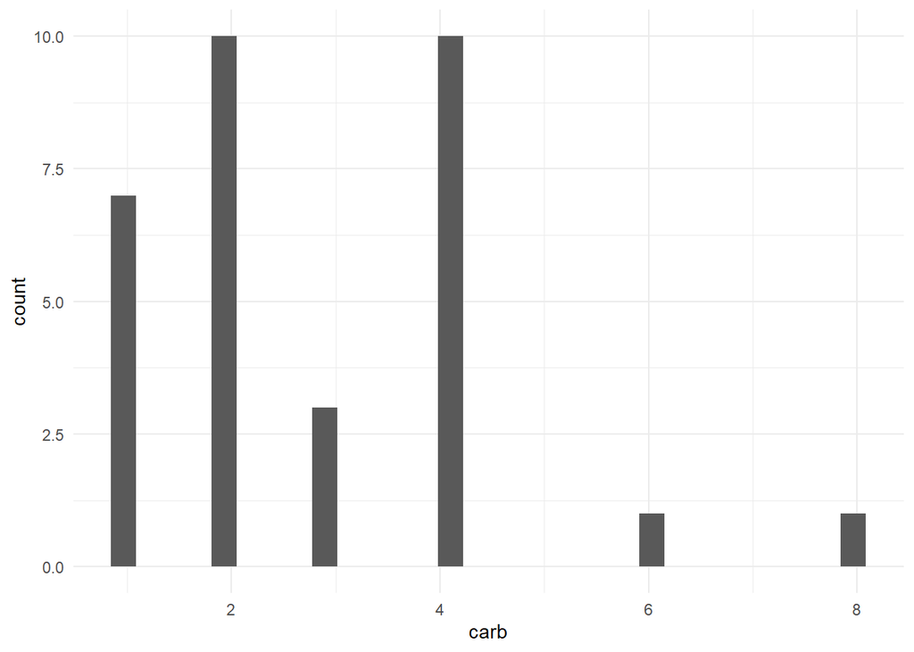

```r
for (i in 1:ncol(mtcars)) {
  p <- ggplot(mapping = aes(x = mtcars[[i]])) +
  geom_histogram() +
  labs(x = names(mtcars[i])) +
  theme_minimal()
  print(p)
}
```

## Problem 5

Calculate the minimum for each column in a `data.frame`. Either though a small script or a function.

For example the data:

```r
library(tidyverse)
tibble(x = 1:3,
       y = c(500,60,70))
```

```
## # A tibble: 3 x 2
##       x     y
##   <int> <dbl>
## 1     1   500
## 2     2    60
## 3     3    70
```

Should give the result:

```r
tibble(x = 1, y = 60)
```

```
## # A tibble: 1 x 2
##       x     y
##   <dbl> <dbl>
## 1     1    60
```

**Solution 1**

```r
df <- tibble(x = 1:3,
       y = c(500,60,70))
```

```r
df %>% map_dfr(min)
```

```
## # A tibble: 1 x 2
##       x     y
##   <int> <dbl>
## 1     1    60
```

```r
apply(X = df, MARGIN = 2, min)
```

```
##  x  y
##  1 60
```

```r
df %>%
  summarise(x = min(x),
            y = min(y))
```

```
## # A tibble: 1 x 2
##       x     y
##   <int> <dbl>
## 1     1    60
```

```r
df %>%
  summarise_all(.funs = min)
```

```
## # A tibble: 1 x 2
##       x     y
##   <int> <dbl>
## 1     1    60
```

## Problem 6

Can you expand the idea in problem 2 into creating a function or small code chunck, that calculates the “paiwise” (or index-wise) mean across any given number of vectors? Inspired by the `pmin` function:

```r
pmin(
  c(1,3,10,5),
  c(4,2,11,3))
```

```
## [1]  1  2 10  3
```

```r
pmin(
  c(1,3,10,5),
  c(4,2,11,3),
  c(7,-2,9,8))
```

```
## [1]  1 -2  9  3
```

**Solution 1**

```r
l <- list(
  c(1,3,10,5),
  c(4,2,11,3),
  c(7,-2,9,8)
)

l
```

```
## [[1]]
## [1]  1  3 10  5
##
## [[2]]
## [1]  4  2 11  3
##
## [[3]]
## [1]  7 -2  9  8
```

```r
l
```

```
## [[1]]
## [1]  1  3 10  5
##
## [[2]]
## [1]  4  2 11  3
##
## [[3]]
## [1]  7 -2  9  8
```

```r
pmap(.l = l, .f = c) %>%
  map_dbl(.f = mean)
```

```
## [1]  4.000000  1.000000 10.000000  5.333333
```